# Western Atlantic mackerel adults parameters for DEPM

mkorta modified from DEPM_mackerel_script of PSanpedro

4/7/2023

*Lola Garabana. Presentation WGMEGS meeting,April 17-21 Madrid.*

# 1 Raw Data Summary

## 1.1 Tables

**By period**

Sampled by period.

| Period | nHaul | nFish | R_nFish | D_nFish | nMatFem | nSpawFem | nMatFem_C | nMatFem_H | nPOFAge | nNcent |
| --- | --- | --- | --- | --- | --- | --- | --- | --- | --- | --- |
| 2 | 12 | 439 | 439 | 0 | 225 | 34 | 86 | 0 | 39 | 0 |
| 3 | 60 | 3369 | 3260 | 109 | 1775 | 173 | 879 | 0 | 461 | 29 |
| 4 | 11 | 930 | 917 | 13 | 457 | 111 | 371 | 0 | 250 | 11 |
| 5 | 16 | 816 | 731 | 85 | 313 | 98 | 171 | 0 | 118 | 4 |
| 6 | 8 | 331 | 303 | 28 | 132 | 25 | 72 | 0 | 39 | 0 |
| 7 | 9 | 165 | 165 | 0 | 50 | 11 | 26 | 0 | 14 | 1 |
| Total | 116 | 6050 | 5815 | 235 | 2952 | 452 | 1605 | 0 | 921 | 45 |

```r
# ---- Legend ------ #

# nHaul:     No. of hauls.
# nFish:     No. of individual fish measured.
# R_nFish:   No. of individual fish randomly sampled and measured.
# D_nFish:   No. of individual fish sampled by direct sampling and measured.
# nMatFem:   No. of mature females.
# nSpawFem:  No. of mature females in maturity stage 4 (Hydrated).
# nMatFem_C: No. of ovaries from mature females that were collected.
# nMatFem_H: No. of ovaries from collected mature females that were histologically screened.
# nPOFAge:   No. of ovaries assigned as "with presence of POF" in histological screening.
# nNcent:    No. of ovaries analysed for batch fecundity.

# ------------------ #
```

**By haul**

Samples by Haul.

Period

Haul

Long

Lat

country

nFish

nFemales

nMatFem

nSpawFem

nMatFem_C

nMatFem_H

nPOFAge

nNcent

2

2022DK_MEGS_008

-9.015000

41.78170

DTU

100

58

58

34

30

0

7

0

2

5

-7.196700

36.91500

IPMA

36

18

18

0

0

0

0

0

2

9

-8.350000

36.88500

IPMA

52

14

14

0

11

0

8

0

2

14

-8.983300

37.96830

IPMA

6

2

2

0

1

0

1

0

2

20

-9.411700

40.18000

IPMA

3

0

0

0

0

0

0

0

2

21

-9.053300

41.47170

IPMA

13

11

11

0

11

0

9

0

2

23

-8.975000

41.63170

IPMA

40

22

22

0

22

0

13

0

2

24

-9.376700

42.69500

IPMA

29

6

6

0

6

0

5

0

2

2022032_2

-5.250000

59.60000

WMR

40

24

23

0

5

0

1

0

2

2022032_2

-5.766667

59.53333

WMR

40

24

23

0

5

0

1

0

2

2022032_4

-5.766667

59.53333

WMR

50

26

25

0

2

0

0

0

2

2022032_5

-6.200000

59.33333

WMR

50

29

28

0

4

0

1

0

2

2022032_7

-6.383333

59.20000

WMR

50

27

24

0

0

0

0

0

3

1

-4.890000

46.75000

AZTI

200

134

134

19

65

0

28

5

3

2

-4.890000

46.75000

AZTI

30

11

11

2

11

0

6

0

3

3

-6.122000

47.34350

AZTI

153

72

72

16

54

0

29

3

3

4

-7.120000

46.92000

AZTI

264

122

121

20

91

0

56

5

3

6

-9.575700

48.67670

AZTI

158

66

66

35

60

0

52

10

3

7

-4.152800

46.25120

AZTI

91

52

52

9

50

0

49

0

3

8

-3.009500

45.35050

AZTI

6

6

6

2

6

0

6

0

3

Careva0322-0004

-6.440000

43.72000

IEO

105

46

46

15

37

0

37

2

3

Careva0322-0005

-3.940000

43.55000

IEO

73

28

28

5

28

0

20

3

3

Careva0322-0006

-4.810000

43.64000

IEO

100

38

38

15

35

0

25

0

3

Pelacus0322-0010

-4.720000

43.47000

IEO

100

37

37

4

31

0

20

0

3

4

-11.350000

52.25130

MI

264

122

121

20

91

0

56

5

3

159

-10.550000

50.05000

THU

4

2

2

0

2

0

0

0

3

161

-10.280000

49.46000

THU

96

53

53

5

49

0

18

0

3

2022NL5400005

-14.330000

53.30000

WMR

5

4

4

0

4

0

2

1

3

2022NL5400008

-9.750000

55.37000

WMR

7

3

3

0

3

0

1

0

3

2022032_8

-6.383333

59.21667

WMR

40

23

21

0

2

0

0

0

3

2022032_9

-6.450000

59.21667

WMR

40

24

23

0

1

0

1

0

3

2022032_10

-6.500000

59.21667

WMR

40

20

20

0

1

0

0

0

3

2022032_11

-6.466667

59.20000

WMR

50

26

26

0

1

0

0

0

3

2022032_12

-8.166667

58.36667

WMR

40

23

23

0

4

0

1

0

3

2022032_13

-8.216667

58.38333

WMR

50

28

28

0

6

0

1

0

3

2022032_14

-8.850000

58.18333

WMR

50

25

23

0

3

0

1

0

3

2022032_15

-9.266667

57.93333

WMR

40

22

19

0

1

0

1

0

3

2022032_16

-8.800000

58.15000

WMR

12

10

9

0

0

0

0

0

3

2022032_17

-9.000000

58.01667

WMR

48

28

26

0

4

0

2

0

3

2022032_18

-9.366667

57.78333

WMR

50

24

24

0

4

0

0

0

3

2022032_19

-9.366667

57.76667

WMR

50

36

36

0

4

0

1

0

3

2022032_20

-9.183333

57.06667

WMR

50

34

34

1

3

0

1

0

3

2022032_21

-9.166667

57.03333

WMR

50

27

27

0

7

0

1

0

3

2022033_03

-10.416667

54.63333

WMR

50

28

28

2

10

0

2

0

3

2022033_04

-10.366667

54.65000

WMR

50

27

27

0

11

0

2

0

3

2022033_05

-10.400000

54.63333

WMR

50

29

29

1

14

0

3

0

3

2022033_06

-10.400000

54.66667

WMR

50

29

26

2

8

0

3

0

3

2022033_07

-10.400000

54.65000

WMR

50

24

24

2

13

0

3

0

3

2022033_08

-10.366667

54.66667

WMR

50

26

26

0

10

0

3

0

3

2022033_10

-10.583333

54.36667

WMR

50

31

28

2

6

0

3

0

3

2022033_11

-10.566667

54.50000

WMR

50

33

33

1

11

0

2

0

3

2022033_13

-10.650000

54.31667

WMR

50

28

28

4

9

0

2

0

3

2022033_14

-10.666667

54.35000

WMR

50

28

28

1

13

0

3

0

3

2022033_15

-10.833333

54.03333

WMR

50

29

29

0

20

0

7

0

3

2022033_16

-10.750000

54.15000

WMR

50

31

31

0

14

0

6

0

3

2022033_17

-10.866667

53.98333

WMR

50

27

27

0

9

0

4

0

3

2022033_18

-11.016667

53.78333

WMR

50

25

25

0

6

0

2

0

3

2022033_19

-11.000000

54.01667

WMR

50

25

25

0

12

0

3

0

3

2022033_20

-11.000000

53.81667

WMR

50

27

27

0

18

0

8

0

3

2022033_21

-11.050000

53.75000

WMR

50

25

25

0

12

0

4

0

3

2022033_22

-10.866667

53.88333

WMR

50

22

22

0

7

0

3

0

3

2022033_24

-11.200000

53.70000

WMR

50

29

29

2

15

0

6

0

3

2022033_25

-10.733333

54.10000

WMR

50

30

29

3

16

0

6

0

3

2022033_26

-10.900000

53.91667

WMR

50

31

31

2

10

0

3

0

3

2022033_27

-10.950000

53.76667

WMR

25

15

15

0

7

0

1

0

3

2022033_28

-10.983333

53.73333

WMR

50

23

23

0

7

0

4

0

3

2022033_29

-11.050000

53.63333

WMR

50

31

31

0

13

0

3

0

3

2022033_30

-11.033333

53.68333

WMR

50

27

26

0

7

0

4

0

3

2022033_31

-11.033333

53.60000

WMR

40

26

26

1

10

0

4

0

3

2022033_32

-11.066667

53.65000

WMR

25

20

20

2

7

0

1

0

3

2022033_33

-11.100000

53.70000

WMR

15

7

7

0

3

0

2

0

3

2022033_34

-11.066667

53.66667

WMR

20

14

14

0

7

0

2

0

3

2022033_35

-10.933333

53.75000

WMR

40

20

19

0

8

0

3

0

3

2022033_36

-11.083333

53.68333

WMR

35

22

22

0

14

0

5

0

4

Careva0322-0002

-11.340000

52.20000

IEO

103

57

57

16

39

0

39

1

4

Pelacus0322-0014

-8.740000

43.35000

IEO

40

10

10

1

1

0

1

0

4

Jureva0422-0003

-8.000000

43.93000

IEO

58

33

33

0

33

0

15

1

4

Jureva0422-0005

-6.910000

43.78000

IEO

100

42

32

0

32

0

14

0

4

Jureva0422-0006

-8.520000

43.53000

IEO

86

37

37

14

37

0

30

4

4

Pelacus0322-0020

-9.040000

43.39000

IEO

100

52

52

17

35

0

26

1

4

Pelacus0322-0024

-4.690000

43.43000

IEO

103

62

62

15

39

0

35

2

4

Pelacus0322-0026

-3.350000

43.45000

IEO

107

47

47

15

39

0

28

2

4

3

-2.530000

43.53000

IPMA

153

72

72

16

54

0

29

3

4

196

-10.200000

51.12000

THU

100

55

55

14

50

0

32

0

4

206

-11.340000

52.20000

THU

100

55

55

19

51

0

25

0

5

9

-5.711200

43.71570

AZTI

52

14

14

0

11

0

8

0

5

10

-4.929000

43.53800

AZTI

52

28

28

3

28

0

28

0

5

11

-1.550300

44.12150

AZTI

9

1

1

1

1

0

0

0

5

22200006

-5.404000

59.77600

HAVFO

174

39

31

13

16

0

13

0

5

22200063

-8.040600

60.74100

HAVFO

111

47

47

27

15

0

14

3

5

AE22001

-8.040600

60.74100

MSS

100

42

42

19

30

0

18

0

5

SC22004

-9.300000

56.75000

MSS

100

52

52

8

21

0

8

0

5

SC22006

-10.374500

54.79000

MSS

4

2

2

0

2

0

1

0

5

SC22008

-14.175200

56.75010

MSS

2

0

0

0

0

0

0

0

5

SC22009

-17.177000

57.75700

MSS

5

2

2

1

2

0

1

0

5

AE22010

-13.291000

58.73600

MSS

4

1

0

0

0

0

0

0

5

2022NL5400601

-1.550300

44.12150

WMR

100

52

52

14

15

0

9

1

5

2022NL5400603

-10.950000

50.73330

WMR

2

2

2

0

2

0

0

0

5

2022NL5400604

-7.400000

47.73330

WMR

3

0

0

0

0

0

0

0

5

2022NL5400605

-11.166700

49.30000

WMR

100

43

43

9

28

0

16

0

5

2022NL5400606

-11.083300

51.20000

WMR

20

5

5

3

5

0

4

0

6

37305

-12.849500

61.25700

IMR

100

58

50

3

32

0

8

0

6

2022NL5400607

-11.900000

52.73330

WMR

100

57

57

11

35

0

26

0

6

2022NL5400609

-11.250000

51.80000

WMR

25

5

5

0

5

0

5

0

6

2022NL5400610

-10.733300

50.66670

WMR

34

4

4

1

0

0

0

0

6

2022NL5400612

-8.650000

48.23330

WMR

5

1

1

0

0

0

0

0

6

2022NL5400613

-4.516700

46.70000

WMR

2

1

1

0

0

0

0

0

6

2022NL5400614

-5.300000

47.20000

WMR

1

0

0

0

0

0

0

0

6

2022NL5400615

-7.316700

47.75000

WMR

64

14

14

10

0

0

0

0

7

AE22011

-13.348000

53.49280

MSS

1

0

0

0

0

0

0

0

7

AE22012

-10.965000

51.71000

MSS

100

31

31

5

10

0

6

1

7

AE22015

-11.050000

49.32500

MSS

3

1

0

0

0

0

0

0

7

AE22016

-10.768000

50.01600

MSS

35

10

7

1

7

0

2

0

7

AE22017

-10.990000

51.43000

MSS

12

5

5

1

4

0

1

0

7

2022NL5000740

-10.420000

51.27000

WMR

9

4

4

3

4

0

4

0

7

2022NL5000741

-10.880000

51.58000

WMR

1

1

1

0

0

0

0

0

7

2022NL5000743

-11.450000

52.15000

WMR

2

1

1

0

0

0

0

0

7

2022NL5000744

-10.900000

51.48000

WMR

2

1

1

1

1

0

1

0

Total

-1064.265933

6083.75677

6559

3242

3182

488

1766

0

1015

53

## 1.2 Plots

**Geographical distribution of nFish**

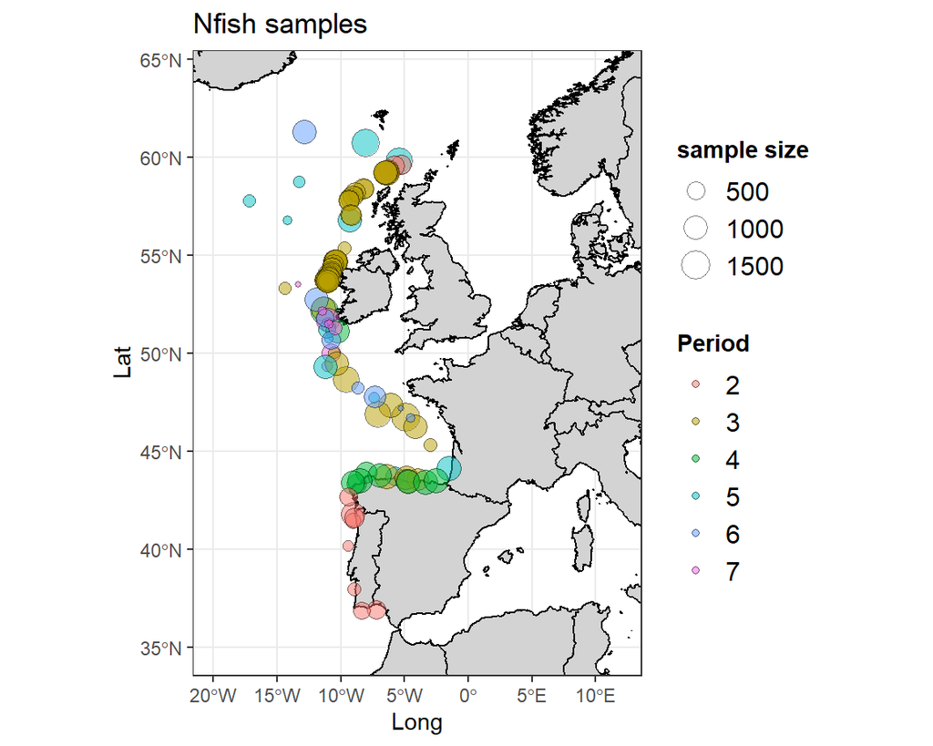

**Length and weight**

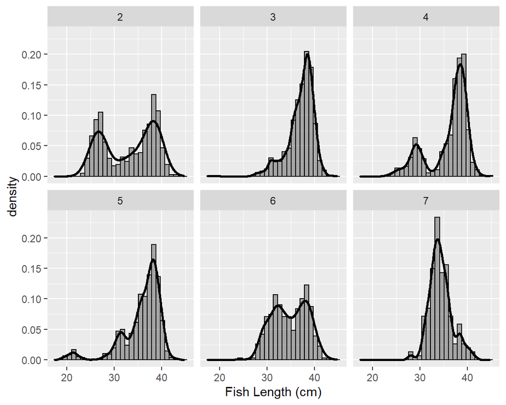

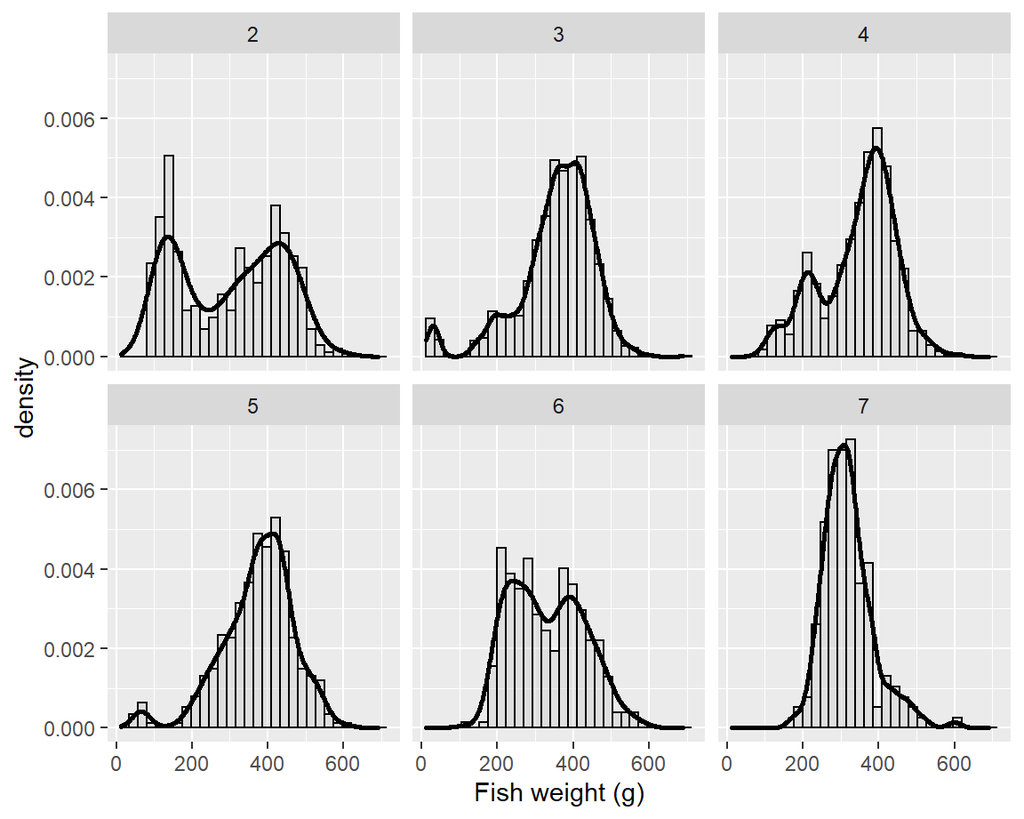

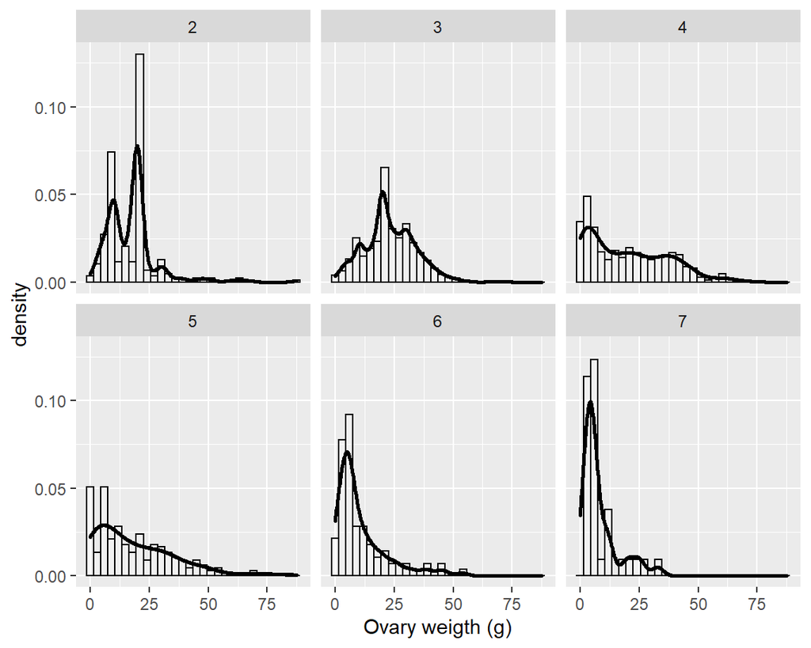

# 2 Paremeters by haul and Period

```r
# Wh:   Mean weight of mature females
# Rh:   Sex-ratio
# Fh:   Batch fecundity (the mean female expected batch fecundity)
# Sh:   Spawning fraction ratio
```

## 2.1 Total Weight correction

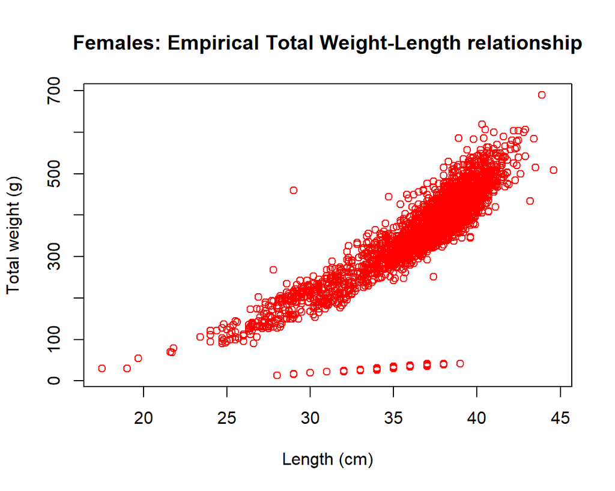

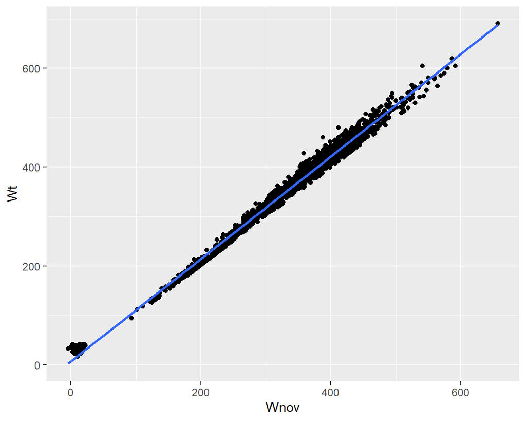

```r
# (Intercept)        Wnov
#  7.795266         1.033756
#  Adjusted R-squared:  0.99
```

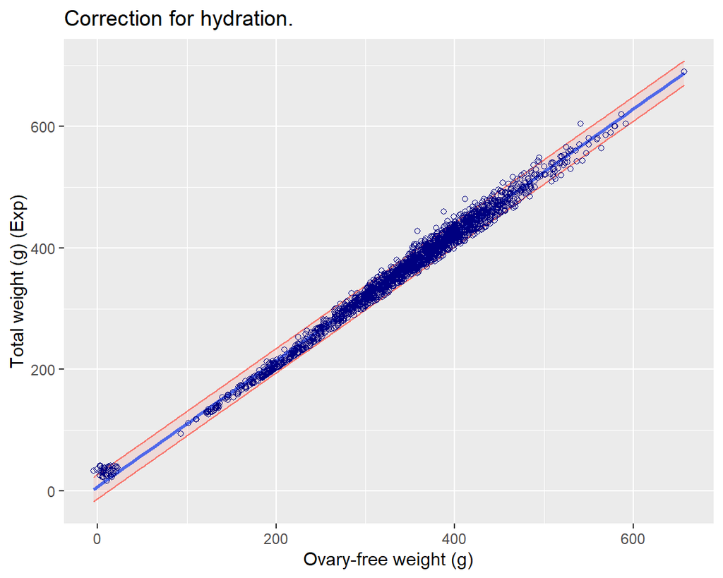

## 2.2 Female mean weight (Wh)

Parameters: Wh by haul (auxiliar).

| Period | Haul | N | nMales | nFemales | n.Females.R | Wh |
| --- | --- | --- | --- | --- | --- | --- |
| 2 | 14 | 6 | 4 | 2 | 2 | NA |
| 2 | 20 | 3 | 3 | 0 | 0 | NA |
| 2 | 2022032_2 | 40 | 15 | 23 | 23 | 453.182 |
| 2 | 2022032_4 | 50 | 23 | 25 | 25 | 408.935 |
| 2 | 2022032_5 | 50 | 21 | 28 | 28 | 450.016 |
| 2 | 2022032_7 | 50 | 21 | 24 | 24 | 372.814 |
| 2 | 2022DK_MEGS_008 | 100 | 42 | 58 | 58 | 356.604 |
| 2 | 21 | 13 | 2 | 11 | 11 | NA |
| 2 | 23 | 40 | 18 | 22 | 22 | 183.839 |
| 2 | 24 | 29 | 23 | 6 | 6 | NA |
| 2 | 5 | 36 | 18 | 18 | 18 | NA |
| 2 | 9 | 22 | 14 | 8 | 14 | NA |
| 3 | 1 | 200 | 66 | 134 | 68 | 410.982 |
| 3 | 159 | 4 | 2 | 2 | 2 | NA |
| 3 | 161 | 96 | 43 | 53 | 53 | 378.062 |
| 3 | 2 | 30 | 18 | 11 | 11 | NA |
| 3 | 2022032_10 | 40 | 18 | 20 | 20 | 416.332 |
| 3 | 2022032_11 | 50 | 23 | 26 | 26 | 421.909 |
| 3 | 2022032_12 | 40 | 16 | 23 | 23 | 427.150 |
| 3 | 2022032_13 | 50 | 22 | 28 | 28 | 426.409 |
| 3 | 2022032_14 | 50 | 24 | 23 | 23 | 412.236 |
| 3 | 2022032_15 | 40 | 14 | 19 | 19 | NA |
| 3 | 2022032_16 | 12 | 1 | 9 | 9 | NA |
| 3 | 2022032_17 | 48 | 19 | 26 | 26 | 384.036 |
| 3 | 2022032_18 | 50 | 26 | 24 | 24 | 415.883 |
| 3 | 2022032_19 | 50 | 14 | 36 | 36 | 410.331 |
| 3 | 2022032_20 | 50 | 16 | 34 | 34 | 440.649 |
| 3 | 2022032_21 | 50 | 23 | 27 | 27 | 414.126 |
| 3 | 2022032_8 | 40 | 15 | 21 | 21 | 422.453 |
| 3 | 2022032_9 | 40 | 15 | 23 | 23 | 428.545 |

[output cut: 86 more lines]

## 2.3 Sex ratio (Rh)

Parameters: Rh by haul (auxiliar).

| Period | Haul | N | nMales | nFemales | n.Females.R | Wh | TotNh | Rh |
| --- | --- | --- | --- | --- | --- | --- | --- | --- |
| 2 | 14 | 6 | 4 | 2 | 2 | NA | 6 | NA |
| 2 | 20 | 3 | 3 | 0 | 0 | NA | 3 | NA |
| 2 | 2022032_2 | 40 | 15 | 23 | 23 | 453.182 | 38 | 0.512 |
| 2 | 2022032_4 | 50 | 23 | 25 | 25 | 408.935 | 48 | 0.513 |
| 2 | 2022032_5 | 50 | 21 | 28 | 28 | 450.016 | 49 | 0.516 |
| 2 | 2022032_7 | 50 | 21 | 24 | 24 | 372.814 | 45 | 0.486 |
| 2 | 2022DK_MEGS_008 | 100 | 42 | 58 | 58 | 356.604 | 100 | 0.523 |
| 2 | 21 | 13 | 2 | 11 | 11 | NA | 13 | NA |
| 2 | 23 | 40 | 18 | 22 | 22 | 183.839 | 40 | 0.544 |
| 2 | 24 | 29 | 23 | 6 | 6 | NA | 29 | 0.508 |
| 2 | 5 | 36 | 18 | 18 | 18 | NA | 36 | NaN |
| 2 | 9 | 22 | 14 | 8 | 14 | NA | 52 | 0.498 |
| 3 | 1 | 200 | 66 | 134 | 68 | 410.982 | 100 | 0.501 |
| 3 | 159 | 4 | 2 | 2 | 2 | NA | 4 | NA |
| 3 | 161 | 96 | 43 | 53 | 53 | 378.062 | 96 | 0.517 |
| 3 | 2 | 30 | 18 | 11 | 11 | NA | 29 | 0.499 |
| 3 | 2022032_10 | 40 | 18 | 20 | 20 | 416.332 | 38 | 0.526 |
| 3 | 2022032_11 | 50 | 23 | 26 | 26 | 421.909 | 49 | 0.510 |
| 3 | 2022032_12 | 40 | 16 | 23 | 23 | 427.150 | 39 | 0.505 |
| 3 | 2022032_13 | 50 | 22 | 28 | 28 | 426.409 | 50 | 0.494 |
| 3 | 2022032_14 | 50 | 24 | 23 | 23 | 412.236 | 47 | 0.503 |
| 3 | 2022032_15 | 40 | 14 | 19 | 19 | NA | 33 | 0.545 |
| 3 | 2022032_16 | 12 | 1 | 9 | 9 | NA | 10 | NA |
| 3 | 2022032_17 | 48 | 19 | 26 | 26 | 384.036 | 45 | 0.532 |
| 3 | 2022032_18 | 50 | 26 | 24 | 24 | 415.883 | 50 | 0.502 |
| 3 | 2022032_19 | 50 | 14 | 36 | 36 | 410.331 | 50 | 0.542 |
| 3 | 2022032_20 | 50 | 16 | 34 | 34 | 440.649 | 50 | 0.535 |
| 3 | 2022032_21 | 50 | 23 | 27 | 27 | 414.126 | 50 | 0.509 |
| 3 | 2022032_8 | 40 | 15 | 21 | 21 | 422.453 | 36 | 0.512 |
| 3 | 2022032_9 | 40 | 15 | 23 | 23 | 428.545 | 38 | 0.498 |

[output cut: 86 more lines]

## 2.4 Batch fecundity (Fh)

**Geographical distribution_nCent**

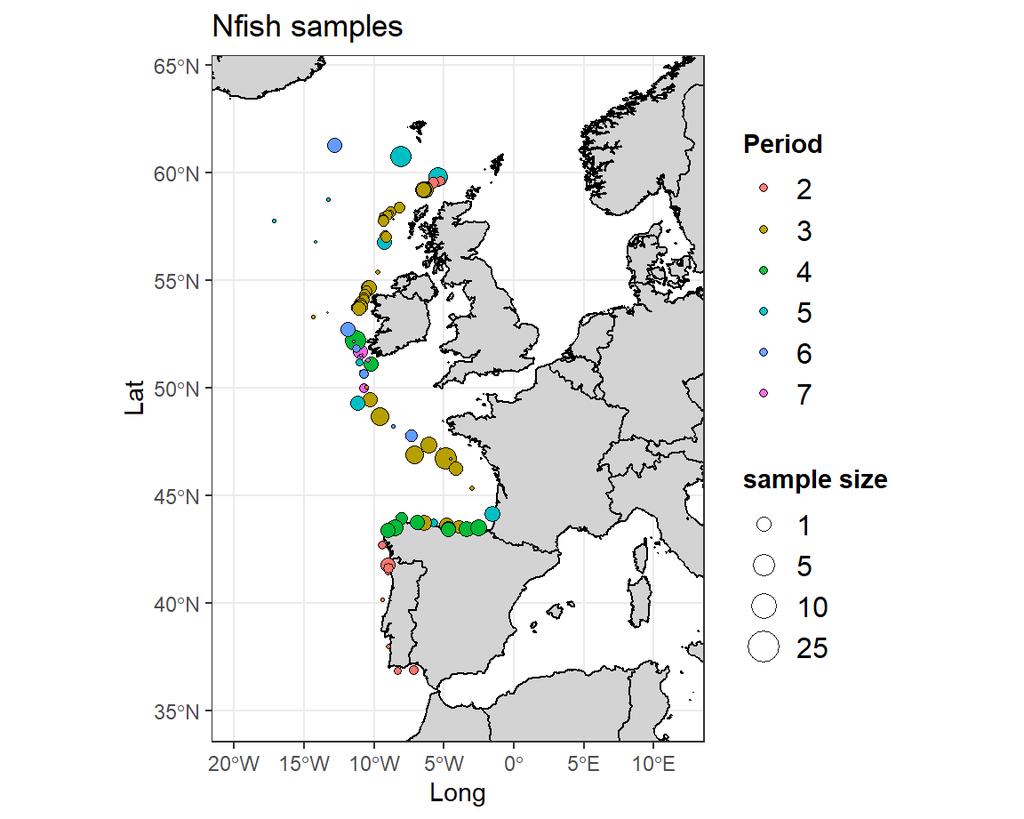

**Fit regression**

```
##
## Call:
## glm.nb(formula = batch.ov ~ Wnov, data = adults.dat, na.action = "na.omit",
##     init.theta = 0.7958807272, link = log)
##
## Deviance Residuals:
##     Min       1Q   Median       3Q      Max
## -2.5518  -1.0672  -0.1527   0.4320   1.6292
##
## Coefficients:
##             Estimate Std. Error z value Pr(>|z|)
## (Intercept) 8.592628   0.578852  14.844   <2e-16 ***
## Wnov        0.001630   0.001628   1.001    0.317
## ---
## Signif. codes:  0 '***' 0.001 '**' 0.01 '*' 0.05 '.' 0.1 ' ' 1
##
## (Dispersion parameter for Negative Binomial(0.7959) family taken to be 1)
##
##     Null deviance: 55.059  on 44  degrees of freedom
## Residual deviance: 53.440  on 43  degrees of freedom
##   (6005 observations deleted due to missingness)
## AIC: 917.6
##
## Number of Fisher Scoring iterations: 1
##
##
##               Theta:  0.796
##           Std. Err.:  0.145
##
##  2 x log-likelihood:  -911.600
```

```
##                 Haul Period   N nMales nFemales n.Females.R      Wh TotNh    Rh
## 1                  1      3 200     66      134          68 410.982   100 0.501
## 2                 10      5  52     24       28          28 348.449    52 0.499
## 3                 11      5   9      8        1           1      NA     9    NA
## 4                 14      2   6      4        2           2      NA     6    NA
## 5                159      3   4      2        2           2      NA     4    NA
## 6                161      3  96     43       53          53 378.062    96 0.517
## 7                196      4 100     45       55          55 403.500   100 0.530
## 8                  2      3  30     18       11          11      NA    29 0.499
## 9                 20      2   3      3        0           0      NA     3    NA
## 10        2022032_10      3  40     18       20          20 416.332    38 0.526
## 11        2022032_11      3  50     23       26          26 421.909    49 0.510
## 12        2022032_12      3  40     16       23          23 427.150    39 0.505
## 13        2022032_13      3  50     22       28          28 426.409    50 0.494
## 14        2022032_14      3  50     24       23          23 412.236    47 0.503
```

[output cut: 219 more lines]

## 2.5 Spawning fraction (Sh)

```
##
##  -9   0   1   2   3
## 161 347 185 104 124
```

Parameters by haul.

| Period | Haul | N | nMales | nFemales | n.Females.R | Wh | TotNh | Rh | Fh | Sh |
| --- | --- | --- | --- | --- | --- | --- | --- | --- | --- | --- |
| 2 | 14 | 6 | 4 | 2 | 2 | NA | 6 | NA | NA | NA |
| 2 | 20 | 3 | 3 | 0 | 0 | NA | 3 | NA | NA | NA |
| 2 | 2022032_2 | 40 | 15 | 23 | 23 | 453.182 | 38 | 0.512 | 10784.701 | NaN |
| 2 | 2022032_4 | 50 | 23 | 25 | 25 | 408.935 | 48 | 0.513 | 10083.478 | 0.200 |
| 2 | 2022032_5 | 50 | 21 | 28 | 28 | 450.016 | 49 | 0.516 | 10683.512 | 0.000 |
| 2 | 2022032_7 | 50 | 21 | 24 | 24 | 372.814 | 45 | 0.486 | 9837.476 | 0.000 |
| 2 | 2022DK_MEGS_008 | 100 | 42 | 58 | 58 | 356.604 | 100 | 0.523 | 9194.745 | 0.333 |
| 2 | 21 | 13 | 2 | 11 | 11 | NA | 13 | NA | NA | NA |
| 2 | 23 | 40 | 18 | 22 | 22 | 183.839 | 40 | 0.544 | 7126.859 | 0.231 |
| 2 | 24 | 29 | 23 | 6 | 6 | NA | 29 | 0.508 | 6619.366 | 0.000 |
| 2 | 5 | 36 | 18 | 18 | 18 | NA | 36 | NaN | NaN | 0.000 |
| 2 | 9 | 22 | 14 | 8 | 14 | NA | 52 | 0.498 | 8636.421 | 0.231 |
| 3 | 1 | 200 | 66 | 134 | 68 | 410.982 | 100 | 0.501 | 10201.590 | 0.143 |
| 3 | 159 | 4 | 2 | 2 | 2 | NA | 4 | NA | NA | NA |
| 3 | 161 | 96 | 43 | 53 | 53 | 378.062 | 96 | 0.517 | 9697.772 | 0.200 |
| 3 | 2 | 30 | 18 | 11 | 11 | NA | 29 | 0.499 | 9323.257 | 0.273 |
| 3 | 2022032_10 | 40 | 18 | 20 | 20 | 416.332 | 38 | 0.526 | 10048.822 | 0.000 |
| 3 | 2022032_11 | 50 | 23 | 26 | 26 | 421.909 | 49 | 0.510 | 10350.306 | 0.000 |
| 3 | 2022032_12 | 40 | 16 | 23 | 23 | 427.150 | 39 | 0.505 | 10462.324 | 0.111 |
| 3 | 2022032_13 | 50 | 22 | 28 | 28 | 426.409 | 50 | 0.494 | 10572.483 | 0.000 |
| 3 | 2022032_14 | 50 | 24 | 23 | 23 | 412.236 | 47 | 0.503 | 10213.535 | 0.000 |
| 3 | 2022032_15 | 40 | 14 | 19 | 19 | NA | 33 | 0.545 | 9253.306 | 0.091 |
| 3 | 2022032_16 | 12 | 1 | 9 | 9 | NA | 10 | NA | NA | NA |
| 3 | 2022032_17 | 48 | 19 | 26 | 26 | 384.036 | 45 | 0.532 | 9577.634 | 0.000 |
| 3 | 2022032_18 | 50 | 26 | 24 | 24 | 415.883 | 50 | 0.502 | 10325.311 | 0.000 |
| 3 | 2022032_19 | 50 | 14 | 36 | 36 | 410.331 | 50 | 0.542 | 9971.933 | 0.000 |
| 3 | 2022032_20 | 50 | 16 | 34 | 34 | 440.649 | 50 | 0.535 | 10430.675 | 0.000 |
| 3 | 2022032_21 | 50 | 23 | 27 | 27 | 414.126 | 50 | 0.509 | 10189.814 | 0.000 |
| 3 | 2022032_8 | 40 | 15 | 21 | 21 | 422.453 | 36 | 0.512 | 10323.729 | 0.200 |
| 3 | 2022032_9 | 40 | 15 | 23 | 23 | 428.545 | 38 | 0.498 | 10576.099 | 0.000 |

[output cut: 86 more lines]

# 3 Population parameters by Period

```r
# W:  Mean weight of mature females
# R:  Sex-ratio
# F:  Batch fecundity = average number of egg by mature female by spawning event (g)
# S:  Spawning fraction
```

## 3.1 Mean Weight

```
##      mean      var        cv
## 1 365.082 116.4582 0.5647937
```

```
## # A tibble: 6 x 4
##   Period  mean   var      cv
## * <fct>  <dbl> <dbl>   <dbl>
## 1 2       372. 1001.   1.64
## 2 3       363.  225.   0.788
## 3 4       347.  636.   1.35
## 4 5       406.  463.   1.07
## 5 6       369. 2846.   2.78
## 6 7       336.  NaN  NaN
```

## 3.2 Mean Sex Ratio

```
##        mean          var          cv
## 1 0.5124994 4.377448e-06 0.002922563
```

```
## # A tibble: 6 x 4
##   Period  mean        var      cv
## * <fct>  <dbl>      <dbl>   <dbl>
## 1 2      0.514 0.0000328  0.00799
## 2 3      0.511 0.00000915 0.00423
## 3 4      0.509 0.0000151  0.00545
## 4 5      0.519 0.0000361  0.00834
## 5 6      0.522 0.0000487  0.00966
## 6 7      0.514 0.00000595 0.00340
```

## 3.3 Mean Batch Fecundity

```
##       mean      var      cv
## 1 9483.762 17520.79 1.35921
```

```
## # A tibble: 6 x 4
##   Period   mean     var    cv
## * <fct>   <dbl>   <dbl> <dbl>
## 1 2       9430. 163613. 4.17
## 2 3       9432.  30383. 1.79
## 3 4       9288. 108781. 3.42
## 4 5      10074. 101464. 3.17
## 5 6       9770. 395189. 6.36
## 6 7       9046.    755. 0.289
```

## 3.4 Mean Spawning fraction

```
##        mean          var         cv
## 1 0.1453345 0.0002417827 0.04078761
```

```
## # A tibble: 6 x 4
##   Period  mean        var       cv
## * <fct>  <dbl>      <dbl>    <dbl>
## 1 2      0.167   0.00433    0.161
## 2 3      0.122   0.000471   0.0621
## 3 4      0.154   0.000836   0.0737
## 4 5      0.186   0.00223    0.109
## 5 6      0.333 NaN        NaN
## 6 7      0.333   0          0
```

# 4 Summary mean parameters

Adult parameters estimates for the 2022 Western Atlantic mackerel DEPM survey.

| Parameter | mean | var | cv |
| --- | --- | --- | --- |
| Female Mean weight | 365.082 | 116.458 | 0.565 |
| Mean Sex Ratio | 0.512 | 0.000 | 0.003 |
| Mean Spawning Fraction | 0.145 | 0.000 | 0.041 |
| Mean batch fecundity | 9483.762 | 17520.792 | 1.359 |
| Mean batch fecundity/g Female (Frel) | 26.336 | NA | NA |
| Daily n.eggs/g Female | 2.020 | NA | NA |

# 5 Summary SSB

```r
# @ https://github.com/GersomCostas/mackerel_adults_MEGS
# @ https://github.com/ices-eg/wg_WGMEGS
```